# JHU-PracticalMLProject

Selin Gokalp

9/16/2020

## Outline of The Project

Used with a dataset provided by Human Activity Recognition (HAR) (http://web.archive.org/web/20161224072740/http:/groupware.les.inf.puc-rio.br/har), a predictive model will be trained to anticipate what exercises were performed by humans using with the dataset, containing 159 different features.

I will follow the outline in this project:

First, I will do data processing on the dataset to be used, then explore it. I will analyze models and select the model after a brief examination to see if the selected model fits my standards. I will conclude this project where I answer the questions, and also predict classification model on the test set which is divided formerly by HAR.

# Data Processing

## Reading the Data

After downloading the data from the data source, we can read the two csv files into two data frames.

```r
TrainDataFirst <- read.csv("pml-training.csv")
TestDataFirst <- read.csv("pml-testing.csv")


dim(TrainDataFirst)
```

```
## [1] 19622   160
```

```r
dim(TestDataFirst)
```

```
## [1]  20 160
```

```r
rm(trainFile)
rm(testFile)
```

The training data set: 19622 observations and 160 variables, while the testing data set: 20 observations and 160 variables. The `classe` variable in the training set is the outcome to predict.

## Cleaning the Data

Since there is lots of NAs and meaningless data points in the dataset, I will remove the NAs from the dataset, as well as some meaningless variables.

First, I clean the Near Zero Variance variables.

```r
NZV <- nearZeroVar(TrainDataFirst, saveMetrics = TRUE)
head(NZV, 20)
```

```
##                        freqRatio percentUnique zeroVar   nzv
## X                       1.000000  100.00000000   FALSE FALSE
## user_name               1.100679    0.03057792   FALSE FALSE
## raw_timestamp_part_1    1.000000    4.26562022   FALSE FALSE
## raw_timestamp_part_2    1.000000   85.53154622   FALSE FALSE
## cvtd_timestamp          1.000668    0.10192641   FALSE FALSE
## new_window             47.330049    0.01019264   FALSE  TRUE
## num_window              1.000000    4.37264295   FALSE FALSE
## roll_belt               1.101904    6.77810621   FALSE FALSE
## pitch_belt              1.036082    9.37722964   FALSE FALSE
## yaw_belt                1.058480    9.97349913   FALSE FALSE
## total_accel_belt        1.063160    0.14779329   FALSE FALSE
## kurtosis_roll_belt   1921.600000    2.02323922   FALSE  TRUE
## kurtosis_picth_belt   600.500000    1.61553358   FALSE  TRUE
## kurtosis_yaw_belt      47.330049    0.01019264   FALSE  TRUE
## skewness_roll_belt   2135.111111    2.01304658   FALSE  TRUE
## skewness_roll_belt.1  600.500000    1.72255631   FALSE  TRUE
## skewness_yaw_belt      47.330049    0.01019264   FALSE  TRUE
## max_roll_belt           1.000000    0.99378249   FALSE FALSE
## max_picth_belt          1.538462    0.11211905   FALSE FALSE
## max_yaw_belt          640.533333    0.34654979   FALSE  TRUE
```

```r
training_1 <- TrainDataFirst[, !NZV$nzv]
testing_1 <- TestDataFirst[, !NZV$nzv]


dim(training_1)
```

```
## [1] 19622   100
```

```r
dim(testing_1)
```

```
## [1]  20 100
```

```r
rm(TrainDataFirst)
rm(TestDataFirst)
rm(NZV)
```

2. I remove some features of the dataset since those do not contribute much to the accelerometer measurements.

```r
regex <- grepl("^X|timestamp|user_name", names(training_1)) #I won't do anything with user_name

training <- training_1[, !regex]
testing <- testing_1[, !regex]


rm(regex)
rm(training_1)
rm(testing_1)
dim(training)
```

```
## [1] 19622    95
```

```r
dim(testing)
```

```
## [1] 20 95
```

3. I drop the columns that containing NA values.

```r
cond <- (colSums(is.na(training)) == 0) #set my conditions to find NAs

training <- training[, cond] #apply my conditional arguments and drop the NAs
testing <- testing[, cond] #apply my conditional arguments and drop the NAs

rm(cond)
```

The correlation matrix of columns in the training data can be seen as:

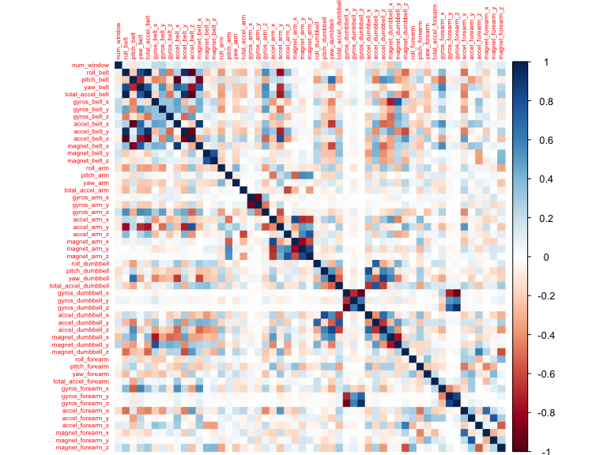

```r
corrplot(cor(training[, -length(names(training))]), method = "color", tl.cex = 0.5)
```

## Partitioning Training Set

I split the cleaned training data with the proportin of 70% to a pure training data set, thus a validation data set now contains 30% of the whole cleaned data set. To apply cross validation to the data, I will use my validation data set.

```r
set.seed(22070)


inTrain <- createDataPartition(training$classe, p = 0.70, list = FALSE) #split 70% - 30%
validation <- training[-inTrain, ]
training <- training[inTrain, ]

rm(inTrain)
```

The Dataset now consists of 54 variables with the observations divided as following: 1. Training Data: 13737 observations.  
2. Validation Data: 5885 observations.  
3. Testing Data: 20 observations.

# Modelling the Data

## Decision Tree Model

For activity recognition, I fit a predictive model, such as Decision Tree in this step.

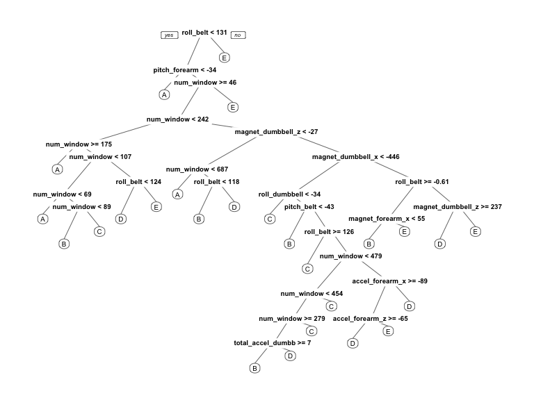

```r
DecTreeModel <- rpart(classe ~ ., data = training, method = "class")

prp(DecTreeModel)
```

I would better to see the performance results of the model on the validation dataset that I split above. To do that, I want to see the performance metrics: Sensitivity, Specificity, Positive and Negative PRedicted Values, Prevalence and Detection Rate and Prevalence.

```r
predictTree <- predict(DecTreeModel, validation, type = "class")

confusionMatrix(validation$classe, predictTree)
```

```
## Confusion Matrix and Statistics
##
##           Reference
## Prediction    A    B    C    D    E
##          A 1422  159    0   76   17
##          B   91  854   60   51   83
##          C    1   85  836   92   12
##          D   15   94   40  754   61
##          E    5   48    6   70  953
##
## Overall Statistics
##
##                Accuracy : 0.8189
##                  95% CI : (0.8088, 0.8286)
##     No Information Rate : 0.2607
##     P-Value [Acc > NIR] : < 2.2e-16
##
##                   Kappa : 0.7716
##
##  Mcnemar's Test P-Value : < 2.2e-16
##
## Statistics by Class:
##
##                      Class: A Class: B Class: C Class: D Class: E
## Sensitivity            0.9270   0.6887   0.8875   0.7229   0.8464
## Specificity            0.9421   0.9386   0.9616   0.9566   0.9729
## Pos Pred Value         0.8495   0.7498   0.8148   0.7822   0.8808
## Neg Pred Value         0.9734   0.9187   0.9782   0.9413   0.9640
## Prevalence             0.2607   0.2107   0.1601   0.1772   0.1913
## Detection Rate         0.2416   0.1451   0.1421   0.1281   0.1619
## Detection Prevalence   0.2845   0.1935   0.1743   0.1638   0.1839
## Balanced Accuracy      0.9345   0.8137   0.9245   0.8398   0.9096
```

```r
accuracy <- postResample(predictTree, validation$classe)
ose <- 1 - as.numeric(confusionMatrix(validation$classe, predictTree)$overall[1])


rm(predictTree)
rm(DecTreeModel)
```

## Random Forest Model

```r
RandForModel <- train(classe ~ ., data = training, method = "rf", trControl = trainControl(method = "cv", 4), ntree = 250)

RandForModel
```

```
## Random Forest
##
## 13737 samples
##    53 predictor
##     5 classes: 'A', 'B', 'C', 'D', 'E'
##
## No pre-processing
## Resampling: Cross-Validated (4 fold)
## Summary of sample sizes: 10302, 10303, 10303, 10303
## Resampling results across tuning parameters:
##
##   mtry  Accuracy   Kappa
##    2    0.9922107  0.9901462
##   27    0.9961418  0.9951196
##   53    0.9941765  0.9926333
##
## Accuracy was used to select the optimal model using the largest value.
## The final value used for the model was mtry = 27.
```

The performance results of this algorithm can be found as:

```r
predictRF <- predict(RandForModel, validation)

confusionMatrix(validation$classe, predictRF)
```

```
## Confusion Matrix and Statistics
##
##           Reference
## Prediction    A    B    C    D    E
##          A 1673    1    0    0    0
##          B    1 1137    1    0    0
##          C    0    2 1024    0    0
##          D    0    0    2  962    0
##          E    0    0    0    0 1082
##
## Overall Statistics
##
##                Accuracy : 0.9988
##                  95% CI : (0.9976, 0.9995)
##     No Information Rate : 0.2845
##     P-Value [Acc > NIR] : < 2.2e-16
##
##                   Kappa : 0.9985
##
##  Mcnemar's Test P-Value : NA
##
## Statistics by Class:
##
##                      Class: A Class: B Class: C Class: D Class: E
## Sensitivity            0.9994   0.9974   0.9971   1.0000   1.0000
## Specificity            0.9998   0.9996   0.9996   0.9996   1.0000
## Pos Pred Value         0.9994   0.9982   0.9981   0.9979   1.0000
## Neg Pred Value         0.9998   0.9994   0.9994   1.0000   1.0000
## Prevalence             0.2845   0.1937   0.1745   0.1635   0.1839
## Detection Rate         0.2843   0.1932   0.1740   0.1635   0.1839
## Detection Prevalence   0.2845   0.1935   0.1743   0.1638   0.1839
## Balanced Accuracy      0.9996   0.9985   0.9983   0.9998   1.0000
```

```r
accuracy <- postResample(predictRF, validation$classe)
ose <- 1 - as.numeric(confusionMatrix(validation$classe, predictRF)$overall[1])


rm(predictRF)
```

The Estimated Accuracy of the Random Forest Model is 99.8810535% and the Estimated Out-of-Sample Error is 0.1189465%.  
We expected that the Random Forest would perform better, and so it does in practice.

# Predicting the Human Exercises from the Test Data Set

I perform Random Forest model to the testing data set downloaded from the data source, not the splitting dataset but the originally downloaded from the HAR.

```r
rm(accuracy)
rm(ose)


predict(RandForModel, testing[, -length(names(testing))])
```

```
##  [1] B A B A A E D B A A B C B A E E A B B B
## Levels: A B C D E
```

## This Part is for Submitting the Project

```r
pml_write_files = function(x){
  n = length(x)
  for(i in 1:n){
    filename = paste0("./Desktop",i,".txt")
    write.table(x[i], file = filename, quote = FALSE, row.names = FALSE, col.names = FALSE)
  }
}
```

```r
pml_write_files(predict(RandForModel, testing[, -length(names(testing))]))

rm(RandForModel)
rm(training)
rm(testing)
rm(validation)
rm(pml_write_files)
```